# Practical Machine Learning Project: Weight Lifting Excercise Dataset

JenBru

April 26, 2016

## Executive Summary

Data about personal activity can be collected relatively inexpensively using devices such as Fitbit, or Nike FuelBand. These data can be used to monitor amounts of activity as well as quantifying how well an activity is performed. This project analyzes 6 participants’ barbell lift excercises based on data from devices worn on the belt, arm, and dumbbell. The participants performed the lifts both correctly and in each of 4 different incorrect ways, which included elbows front, lift halfway, lower halfway, and hips in front. This study aims to correctly classify how participants performed the lifts. The data includes measures of position in the x, y, and z axes as measured from the device’s accelerometer, gyroscope, and magnetometer as well as rotation measures that indicate movement from front to back (roll), side to side (pitch), and around a vertical axis (yaw).

Several prediction methods and features were tested to try to find a strong predicting algorithm to correctly classify the lift. The boosted random forest model performed well, which is encouraging as a potential application of sensor data to measure quality and not just quantity of activity.

## Data

The training and testing data were obtained online from the fileUrls referenced below. The train data contained 19,622 observations on 160 variables. Many of these variables were derived measures and had a lot of missing observations. Rather than impute the derived measures, this study focused on the measures that were collected directly from the device, as well as markers for the participant that performed the lift, and 2 different time stamp indicators. A list of the measures considered for the analyis are in appendix A.

```r
fileUrl <- "https://d396qusza40orc.cloudfront.net/predmachlearn/pml-training.csv"
download.file(fileUrl, destfile = "pml-training.csv")
fileUrl <- "https://d396qusza40orc.cloudfront.net/predmachlearn/pml-testing.csv"
download.file(fileUrl, destfile = "pml-testing.csv")

train <- read.csv("pml-training.csv")
test <- read.csv("pml-testing.csv")
```

It seemed that the variable “classe”, the classifier that we are interested in categorizing, was a hidden variable, meaning that it can be tabulated and referenced, but it does not appear in the list of global variables. This was problematic when subsetting the data because it was dropped out. As such, the following work-around was used.

```r
trainSmall <- train[, c(2, 5, 7:10, 37:48, 60:68, 84:86)]  # mark columns of interest & put in new df
classe <- as.character(train$classe)  # extract (as text) the 'classe' variable from train data
trainNew <- cbind(trainSmall, classe)  # lastly, do cbind to add classe back in
```

Next, the training data was split into two subsets: one for training and one for cross-validation. Sixty percent of the data is retained for training. The createDataPartition function in the caret package is used to create the subsets using random sampling within the levels of “classe” to try to balance the distribution within the subsets.

```r
trainIndex = createDataPartition(trainNew$class, p = 0.6, list = FALSE)
training = trainNew[trainIndex, ]
testing = trainNew[-trainIndex, ]
dim(training)
```

```
## [1] 11776    31
```

```r
dim(testing)
```

```
## [1] 7846   31
```

## Exploratory Data Analysis

To get a sense of the data, some basic analysis was done to check for missing data, and look at means and correlations. Begin by getting some basic summary stats, like mean, by classe. These are computed using the ddply function in the plyr package. The same method was used to look at and compute standard deviations and check for missing values, of which there were none.

```r
# mean:
names<-colnames(training)
classe<-c("A","B","C","D","E")
meansTrain<-as.data.frame(classe)
v<-c(3:30)

fun<-function(variableToSum,i=1:160){
    for(i in v) {
        var<-names[i]
        training$var<-training[,var]
        means<-ddply(training, c("classe"), summarise, mean=mean(var,na.rm=TRUE))
        df<-as.data.frame(means[,2])
        colnames(df)<-var
        meansTrain<<-cbind(meansTrain,df)
    }
}
fun(names)
```

Based on the means by classe computed above, one can observe that the average values for some measures are quite different when performing the lift correctly versus in one of the 4 incorrect ways. A few of the means for such cases are shown below.

```r
meansTrain[,c(1,21,22,24,25,26)]
```

```
##   classe accel_arm_x accel_arm_y magnet_arm_x magnet_arm_y magnet_arm_z
## 1      A  -132.75836    46.39845    -23.90024    238.60544     411.9214
## 2      B   -45.15796    23.50461    228.50548    132.01580     198.9697
## 3      C   -75.95131    40.83106    162.77264    188.55745     358.4211
## 4      D    15.26477    26.65751    394.92746     96.95648     297.2549
## 5      E   -14.26697    13.70208    330.25681     78.53072     206.5404
```

Next, some plots were generated to get a feeling for the distribution of the data, by classe, as well as any possible correlations among potential regressors. A few examples for these plots are shown below for the variables roll_belt, pitch_belt and yaw_belt (figure 1). A plot of the timestamp versus some variables showed interesting cyclical patterns for some variables, including roll_belt (figure 2).

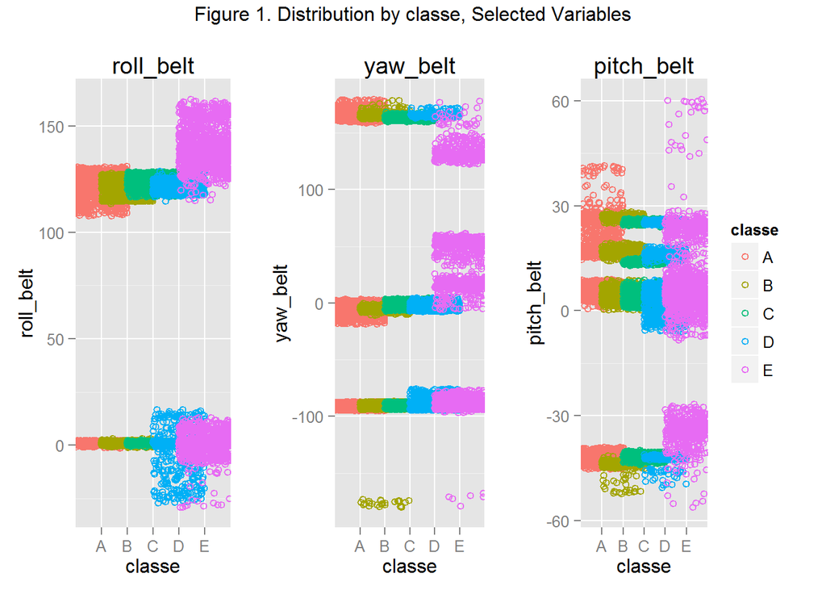

```r
p1 <- ggplot(training, aes(x = classe, y = roll_belt, color = classe)) + geom_point(shape = 1,
    position = position_jitter(width = 1, height = 0.5)) + ggtitle("roll_belt") +
    theme(legend.position = "none")
p2 <- ggplot(training, aes(x = classe, y = yaw_belt, color = classe)) + geom_point(shape = 1,
    position = position_jitter(width = 1, height = 0.5)) + ggtitle("yaw_belt") +
    theme(legend.position = "none")
p3 <- ggplot(training, aes(x = classe, y = pitch_belt, color = classe)) + geom_point(shape = 1,
    position = position_jitter(width = 1, height = 0.5)) + ggtitle("pitch_belt")
grid.arrange(p1, p2, p3, ncol = 3, nrow = 1, top = "Figure 1. Distribution by classe, Selected Variables",
    widths = c(4, 4, 5), heights = c(3))
```

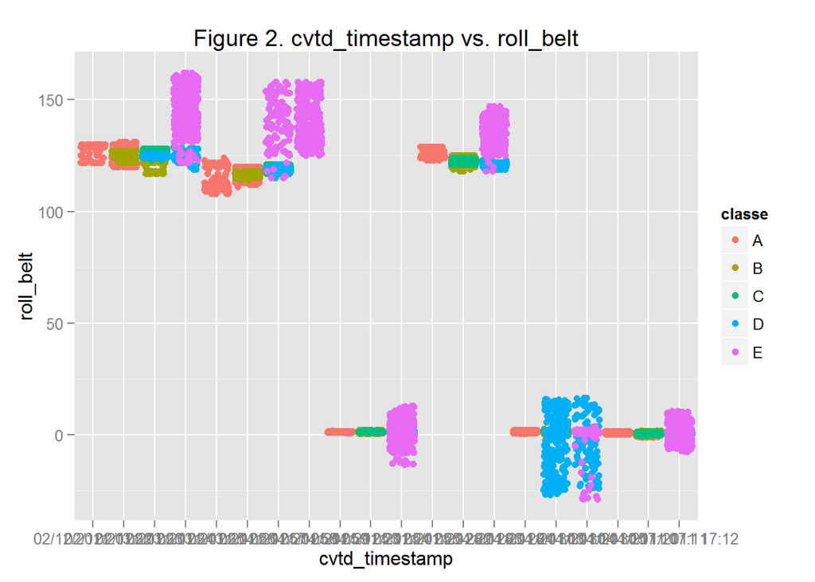

```r
qplot(cvtd_timestamp, roll_belt, data = training, color = classe, geom = "jitter",
    main = "Figure 2. cvtd_timestamp vs. roll_belt")
```

In addition, a correlation matrix was generated to examine correlation coefficients among potential regressors. The first 5 rows and columns of the matrix is shown below. A few potential regressors had somewhat high correlations, which may require more attention when selecting features.

```r
corMatrix<-as.data.frame(cor(training[,c(3:30)]))
corMatrix[c(1:5),c(1:5)]
```

```
##               num_window  roll_belt pitch_belt    yaw_belt gyros_belt_x
## num_window    1.00000000  0.0763840 -0.1066926  0.09122297    0.2148274
## roll_belt     0.07638400  1.0000000 -0.2161480  0.81419035   -0.1141800
## pitch_belt   -0.10669264 -0.2161480  1.0000000 -0.69961361   -0.4309734
## yaw_belt      0.09122297  0.8141903 -0.6996136  1.00000000    0.1446022
## gyros_belt_x  0.21482743 -0.1141800 -0.4309734  0.14460215    1.0000000
```

## Model Development

The key decisions made in the development of the model to predict classe were feature selection and estimation method.

### Feature Selection

The features were chosen to focus on those without a lot of missing values and were limited to those that were primarily derived directly from the device rather than summary statistics of those measures (eg. means, min, max, kurtosis, variance, standard deviation). ( See appendix A for a list of the variables considred for use in the model,which are referenced as “.”" in the models that follow in this section.) A single timestamp variable (cvtd_timestamp) was selected for inclusion and was found to be a very important predictor. Variables with low importance, as indicated by the mean gini coefficient, were excluded and several of these were noted to have high correlations with other regressors.

### Estimation method

The analysis began with a random forest method due to its reputation as a high performing prediction model, though it is sometimes lacking in interpretability. A multinomial logit was also tested, as a potentially more interpretable alternative, but it was ultimately found to be a weak predictor. Lastly, a boosted random forest method was tested to try to improve prediction accuracy.

### Model Development

#### Random Forest

We begin by testing a random forest model using all available regressors based on device measurements in our training data (see appendix A). The randomForest function from the randomForest package is used. The randomForest function was used rather than caret due to the very long processing times used by caret to fit the model, which ran for hours without converging to a solution for a single model.

```r
rf1<-randomForest(classe~.,data=training)
rf1
```

[output not shown]

```r
importance(rf1)
```

```
##                MeanDecreaseGini
## user_name             189.03336
## cvtd_timestamp       1795.48747
## num_window           1123.12169
## roll_belt             769.65234
## pitch_belt            499.69147
## yaw_belt              602.49669
## gyros_belt_x           83.18433
## gyros_belt_y           80.61278
## gyros_belt_z          176.21092
## accel_belt_x          120.07935
## accel_belt_y          108.41701
## accel_belt_z          289.51220
## magnet_belt_x         207.34571
## magnet_belt_y         302.90318
## magnet_belt_z         310.57619
## roll_arm              261.59823
## pitch_arm             137.51090
## yaw_arm               152.25390
## gyros_arm_x            91.57311
## gyros_arm_y            93.66724
## gyros_arm_z            42.44638
## accel_arm_x           203.77588
## accel_arm_y           120.19126
## accel_arm_z           107.00427
## magnet_arm_x          171.94811
## magnet_arm_y          159.85381
## magnet_arm_z          139.27920
## roll_dumbbell         436.99560
## pitch_dumbbell        246.42467
## yaw_dumbbell          287.37959
```

Alternative random forest models that were tested primarily focused on removing single variables that had correlations with 1 or more other variables of .75 or higher (specifically, magnet_arm_y, magnet_arm_z, accel_arm_y, accel_belt_z,gyros_arm_x, gyros_arm_y, accel_belt_y, and accel_belt_x.) None of these improved accuracy in prediction.

```r
rf2 <- randomForest(classe ~ . - gyros_belt_x - gyros_belt_y - accel_belt_x -
    accel_belt_y - gyros_arm_x - gyros_arm_y - gyros_arm_z - accel_arm_z, data = training)
rf2
```

```
##
## Call:
##  randomForest(formula = classe ~ . - gyros_belt_x - gyros_belt_y -      accel_belt_x - accel_belt_y - gyros_arm_x - gyros_arm_y -      gyros_arm_z - accel_arm_z, data = training)
##                Type of random forest: classification
##                      Number of trees: 500
## No. of variables tried at each split: 4
##
##         OOB estimate of  error rate: 0.27%
## Confusion matrix:
##      A    B    C    D    E  class.error
## A 3347    1    0    0    0 0.0002986858
## B    2 2274    3    0    0 0.0021939447
## C    2    5 2040    7    0 0.0068159688
## D    0    0    5 1924    1 0.0031088083
## E    0    0    0    6 2159 0.0027713626
```

```r
predictRF2 <- predict(rf2, newdata = testing, type = "class")
confusionMatrix(predictRF2, testing$classe)
```

```
## Confusion Matrix and Statistics
##
##           Reference
## Prediction    A    B    C    D    E
##          A 2232    0    0    0    0
##          B    0 1516    4    0    0
##          C    0    2 1361    4    0
##          D    0    0    3 1282    3
##          E    0    0    0    0 1439
##
## Overall Statistics
##
##                Accuracy : 0.998
##                  95% CI : (0.9967, 0.9988)
##     No Information Rate : 0.2845
##     P-Value [Acc > NIR] : < 2.2e-16
##
##                   Kappa : 0.9974
##  Mcnemar's Test P-Value : NA
##
## Statistics by Class:
##
##                      Class: A Class: B Class: C Class: D Class: E
## Sensitivity            1.0000   0.9987   0.9949   0.9969   0.9979
## Specificity            1.0000   0.9994   0.9991   0.9991   1.0000
## Pos Pred Value         1.0000   0.9974   0.9956   0.9953   1.0000
## Neg Pred Value         1.0000   0.9997   0.9989   0.9994   0.9995
## Prevalence             0.2845   0.1935   0.1744   0.1639   0.1838
## Detection Rate         0.2845   0.1932   0.1735   0.1634   0.1834
## Detection Prevalence   0.2845   0.1937   0.1742   0.1642   0.1834
## Balanced Accuracy      1.0000   0.9990   0.9970   0.9980   0.9990
```

#### Multinomial logit

In addition to testing alternative specifications of a random forest model, a multinomial logit was also tested using the multinom function of the nnet package. The results were much less accurate at predicting classe than the random forest model.

```r
    mn1<-multinom(classe~.-gyros_belt_x-gyros_belt_y-accel_belt_x-accel_belt_y-gyros_arm_x-gyros_arm_y-gyros_arm_z-accel_arm_z,data=training)
```

```r
    p<-predict(mn1,type="class",newdata=testing)
    postResample(testing$classe,p)
```

```
##  Accuracy     Kappa
## 0.7982411 0.7450283
```

#### Boosted Random Forest

The last model type that was tested was a boosted model that used the boosting function from the adabag package, which is a boosting model for more than 2 categories. This model was also tested without the low importance variables noted earlier.

```r
    b1<-boosting(classe~.-gyros_belt_x-gyros_belt_y-accel_belt_x-accel_belt_y-gyros_arm_x-gyros_arm_y-gyros_arm_z-accel_arm_z,data=training)
    summary(b1)
```

```
##            Length Class   Mode
## formula        3  formula call
## trees        100  -none-  list
## weights      100  -none-  numeric
## votes      58880  -none-  numeric
## prob       58880  -none-  numeric
## class      11776  -none-  character
## importance    22  -none-  numeric
## terms          3  terms   call
## call           3  -none-  call
```

```r
    predictB1<-predict(b1,testing)
    # compute accuracy by hand because it does not appear to be readily available
    cmB1<-as.data.frame(predictB1$confusion)  # put the confusion matrix in a dataframe
    cmb1TotCorrect<-cmB1[which(cmB1$Predicted.Class==cmB1$Observed.Class),] # subset correct predictions
    b1AccNum<-sum(cmb1TotCorrect$Freq) # sum correct predictions
    b1AccDenom<-sum(cmB1$Freq)  # sum all predictions
    B1Accuracy<-b1AccNum/b1AccDenom # find correct share of total predictions (ie. accuracy)
    predictB1$confusion
```

```
##                Observed Class
## Predicted Class    A    B    C    D    E
##               A 2232    0    0    0    0
##               B    0 1517    0    0    0
##               C    0    1 1366    0    0
##               D    0    0    2 1286    1
##               E    0    0    0    0 1441
```

```r
    predictB1$error
```

```
## [1] 0.0005098139
```

```r
    B1Accuracy
```

```
## [1] 0.9994902
```

## Cross-Validation

The cross-validation method used here is a ‘holdout’ method, which is a special case of k-fold cross validation, essentially with only 1 fold. As noted earlier, the sample is randomly assigned within each class to either the training or testing set. For this study, 60% of the data is used for training and 40% for testing, which is a commonly used split. Cross validation is used to evaluate model performance, particularly out of sample error rates and accuracy.

## Model Performance on test set

```r
testB1<-predict(b1,test)
quiz<-as.data.frame(testB1$class)
```

## Discussion and Conclusions

The boosted model, limited to the most important variables derived directly from measures from the device sensor, performed well in correctly predicting the test cases. This is an exciting result, which may encourage more research on classification of activity studies that look at quality, in addition to quantity, of activity.

### Appendix A

Variables to be considered in developing the model.

```r
names
```

```
##  [1] "user_name"      "cvtd_timestamp" "num_window"     "roll_belt"
##  [5] "pitch_belt"     "yaw_belt"       "gyros_belt_x"   "gyros_belt_y"
##  [9] "gyros_belt_z"   "accel_belt_x"   "accel_belt_y"   "accel_belt_z"
## [13] "magnet_belt_x"  "magnet_belt_y"  "magnet_belt_z"  "roll_arm"
## [17] "pitch_arm"      "yaw_arm"        "gyros_arm_x"    "gyros_arm_y"
## [21] "gyros_arm_z"    "accel_arm_x"    "accel_arm_y"    "accel_arm_z"
## [25] "magnet_arm_x"   "magnet_arm_y"   "magnet_arm_z"   "roll_dumbbell"
## [29] "pitch_dumbbell" "yaw_dumbbell"   "classe"
```

### Appendix B

The following packages need to be loaded prior to running the code above.

```r
library(caret)
library(plyr)
library(gridExtra)
library(randomForest)
library(nnet)
library(adabag)
```